# EMDS: Week 10 (parameter recovery)

This notebook contains code for simulation of a temporal discounting task and parameter recovery analysis for a single participant.

Load task parameters from CSV file (for 60 trials). The parameterisation is based on Anderson et al. (2008).

```r
tp <- read.csv('td-params-andersonea.csv')
tp <- tp[-1]
num_trials <- dim(tp)[1]
```

Define some helper functions.

```r
# Discount function (exponential), assumes delay is in months
disc <- function(d, r) {
  if (d > 0){
    util = (1 / (1 + exp(log(r)) / 12) ** (d))
  } else {
    util <- 1
  }
  util
}

# Function to compute discounted utility of amount a received after delay d
# (in months), assuming linear utility and discount rate r (p.a.)
util <- function(a, d, r) {
  util = disc(d, r) * a
}

# Logit (softmax) function
softmax <- function(x, beta) {
  min( max( 1 / (1 + exp(- exp(log(beta)) * x )), 10**(-15) ), 1 - 10**(-15) )
}
```

Simulate responses of simple discounted utility model (assuming linear utility).

```r
# set participant parameters
r = 0.3 # discount rate p.a
beta = 1 # softmax parameter (inverse of variance of logistic distribution)

# vector for responses
choices <- matrix(, num_trials, 3)

# run through trials
for (t in 1:num_trials) {
  # compute utilities of the two options"
  u0 <- util(tp[t,2], tp[t,1], r)
  u1 <- util(tp[t,4], tp[t,3], r)

  # compute probability of choosing first option
  p <- softmax(u1 - u0, beta)

  # convert probability into an actual choice
  c <- rbinom(1, 1, p)

  # write simulated response to choices variable
  choices[t, ] <- c(c, tp[t, 3], tp[t, 4])
}

choices <- data.frame(choices)
colnames(choices) <- c("choice", "delay", "amount")
```

Plot choices by delay.

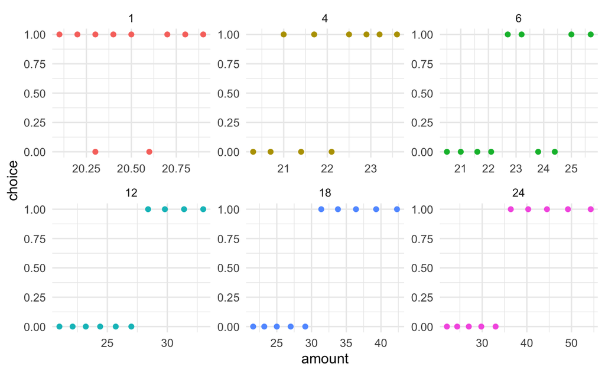

```r
p <- ggplot(choices, aes(amount, choice, colour = factor(delay))) +
  geom_point() + facet_wrap(~ delay, ncol = 3, scales = "free") +
  guides(colour = "none") +
  theme_minimal()
p
```

Let’s estimate the discount rate using maximum likelihood estimation. First, we need to define the likelihood function.

```r
neg_ll <- function(params, choices, tp) {

  neg_ll = 0

  for (t in 1:num_trials) {
    # compute utilities of both options
    u0 <- util(tp[t,2], tp[t,1], params[1])
    u1 <- util(tp[t,4], tp[t,3], params[1])

    # compute probability of choosing first option
    p <- softmax(u1 - u0, params[2])

    # compute log-likelihood
    neg_ll = neg_ll - log(p)**choices[t,1] - log(1-p)**(1-choices[t,1])
  }

  neg_ll
}
```

Let’s plot the log-likelihood function.

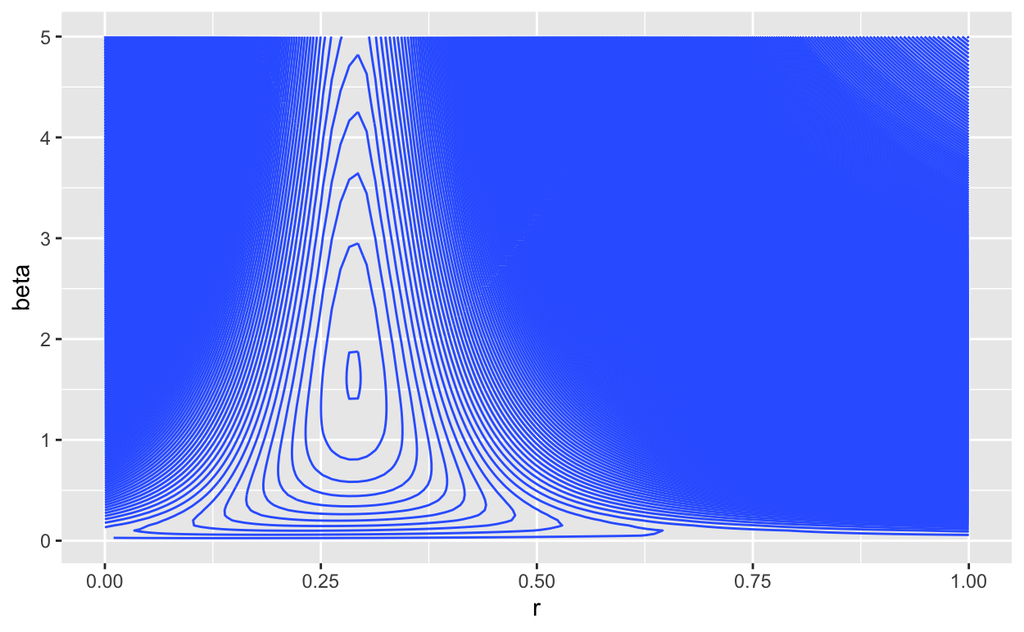

```r
# compute ll
ll_sim <- matrix(, 100 * 100, 3)

r_range <- seq(from = 0, to = 1, length.out = 100)
beta_range <- seq(from = 0, to = 5, length.out = 100)

row <- 0
for (i in 1:length(r_range)) {
  for (j in 1:length(beta_range)) {
    ll_sim[row, 1] <- r_range[i]
    ll_sim[row, 2] <- beta_range[j]
    ll_sim[row, 3] <- neg_ll(c(r_range[i], beta_range[j]), choices, tp)
    row <- row + 1
  }
}
ll_sim <- data.frame(ll_sim)
colnames(ll_sim) <- c("r", "beta", "neg_ll")

# plot neg-LL surface
v <- ggplot(ll_sim, aes(r, beta, z = -neg_ll))
v + geom_contour(binwidth = 2)
```

Now let’s use optimisation to compute the MLE estimate of r and beta.

```r
theta_mle <- optim(c(0.5, 1), neg_ll, choices = choices, tp = tp)
theta_mle
```

```
$par
[1] 0.2878981 1.6348668

$value
[1] -40.14606

$counts
function gradient
      91       NA

$convergence
[1] 0

$message
NULL
```

So that looks good (or does it?). Let’s assess the goodness of fit by plotting actual choices in utility space.

```r
# matrix for predictions
pred_vs_actual <- matrix(, num_trials, 4)
x_range <- seq(from = -5, to = 5, length.out = 100)

# run through trials
for (t in 1:num_trials) {
  # compute utilities of the two options"
  u0 <- util(tp[t,2], tp[t,1], theta_mle$par[1])
  u1 <- util(tp[t,4], tp[t,3], theta_mle$par[1])

  pred_vs_actual[t,1] <- u1 - u0
  pred_vs_actual[t,2] <- choices[t,1]
  pred_vs_actual[t,3] <- choices[t,2]
  pred_vs_actual[t,4] <- softmax(u1 - u0, theta_mle$par[2])
}

pred_vs_actual <- data.frame(pred_vs_actual)
colnames(pred_vs_actual) <- c("delta_u", "choice", "delay", "p")

p <- ggplot(pred_vs_actual, aes(delta_u, choice, colour = factor(delay))) +
  geom_point() +
  guides(colour = "none") +
  geom_line(aes(y=p, group = 1))
  theme_minimal()
```

[output not shown]

[output cut: 329 more lines]

[output not shown]

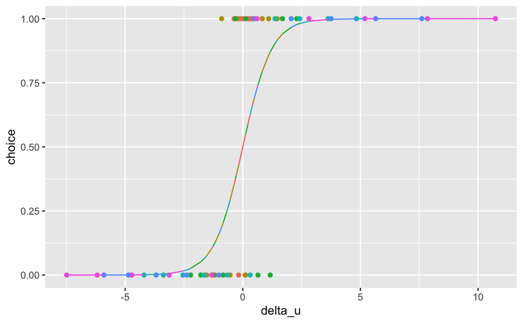

```r
p
```

Let’s do this 100 times and compare actual parameters to estimates.

```r
N = 100
r_est <- matrix(, N, 2)
beta_est <- matrix(, N, 2)

for (n in 1:N) {
  # set participant parameters
  r = rnorm(1, 0.3, 0.03) # discount rate p.a
  beta = rnorm(1, 1, 0.1) # softmax parameter (inverse of variance of logistic distribution)

  # vector for responses
  choices <- matrix(, num_trials, 3)

  # run through trials
  for (t in 1:num_trials) {
    # compute utilities of the two options"
    u0 <- util(tp[t,2], tp[t,1], r)
    u1 <- util(tp[t,4], tp[t,3], r)

    # compute probability of choosing first option
    p <- softmax(u1 - u0, beta)

    # convert probability into an actual choice
    c <- rbinom(1, 1, p)

    # write simulated response to choices variable
    choices[t, ] <- c(c, tp[t, 3], tp[t, 4])
  }

  choices <- data.frame(choices)
  colnames(choices) <- c("choice", "delay", "amount")

  theta_mle <- optim(c(0.5, 1), neg_ll, choices = choices, tp = tp)
  r_est[n,1] <- r
  r_est[n,2] <- theta_mle$par[1]
  beta_est[n,1] <- beta
  beta_est[n,2] <- theta_mle$par[2]
}

r_est <- data.frame(r_est)
colnames(r_est) <- c("actual", "estimate")
beta_est <- data.frame(beta_est)
colnames(beta_est) <- c("actual", "estimate")

p1 <- ggplot(r_est, aes(actual, estimate)) +
  geom_point(color='darkblue') +
  # guides(colour = "none") +
  geom_rug() +
  theme_minimal()
p1

p2 <- ggplot(beta_est, aes(actual, estimate)) +
  geom_point(color='darkblue') +
  # guides(colour = "none") +
  theme_minimal()
p2
```

[output not shown]

Now let’s examine how good parameter recoverability is for a range of model parameters (r in [0,1] and beta in [0,10]). We will construct a grid of 50 values of r from the interval [0,1] and 50 values from the interval [0,10] and compute parameter recoverability for each of the 50x50 gridpoints (using 10 simulations per grid point). What is a good criterion for parameter recoveriability for this kind of analysis? (Try to exploit parallelisation in your computations.)

```r
N = 10
r_range <- seq(from = 0, to = 1, length.out = 50)
beta_range <- seq(from = 0, to = 10, length.out = 50)

# EXERCISE!
```

Let’s fit an alternative model.

```r
# Function to compute discounted utility of amount a received after delay d
# (in months), assuming linear utility and hyperbolic discounting with discount rate r (p.a.)
util_h <- function(a, d, r) {
  util = a / (1 + exp(log(r)) * d / 12)
}

# Negative LL for hyperbolic model
neg_ll_h <- function(params, choices, tp) {

  neg_ll = 0

  for (t in 1:num_trials) {
    # compute utilities of both options
    u0 <- util_h(tp[t,2], tp[t,1], params[1])
    u1 <- util_h(tp[t,4], tp[t,3], params[1])

    # compute probability of choosing first option
    p <- softmax(u1 - u0, params[2])

    # compute log-likelihood
    neg_ll = neg_ll - log(p)**choices[t,1] - log(1-p)**(1-choices[t,1])
  }

  neg_ll
}

# Parameter estimate for hyperbolic model
theta_mle_h <- optim(c(0.5, 1), neg_ll_h, choices = choices, tp = tp)
theta_mle_h
```

[output not shown]

Let’s compare the two models using BIC.

```r
BIC = -2 * -theta_mle$value + 2 * log(num_trials)
BIC_h = -2 * -theta_mle_h$value + 2 * log(num_trials)
print(c(BIC, BIC_h))
```

[output not shown]